# Forecasting Price Movements of iShares MSCI Japan ETF (EWJ)

Roy Wang

Dec 7, 2017

This post presents a simple time series analysis of [iShares MSCI Japan ETF (EWJ)](https://www.ishares.com/us/products/239665/ishares-msci-japan-etf) using autoregressive integrated moving average (ARIMA) models to forecast future price movements.

The iShares MSCI Japan ETF seeks to track the investment results of MSCI Japan Index, which consists of stocks traded primarily on the Tokyo Stock Exchange. A summary prospectus can be found here.

## Data retrieval and exploration

Due to the limits on data retrieval from Yahoo! Finance, our data dates back to only January 03, 2007.

```r
library(quantmod)
library(dplyr)
ts <- getSymbols("EWJ", src = "yahoo", auto.assign = FALSE) %>% Cl() # Retrieve and extract the ETF's closing price data from Yahoo! Finance
sum(is.na(ts)) # Check for missing data
```

```
[1] 0
```

```r
head(ts) # View the first few rows
```

```
           EWJ.Close
2007-01-03     56.80
2007-01-04     57.40
2007-01-05     55.92
2007-01-08     56.24
2007-01-09     56.60
2007-01-10     55.76
```

```r
tail(ts) # View the last few rows
```

```
           EWJ.Close
2017-11-29     59.85
2017-11-30     59.91
2017-12-01     59.64
2017-12-04     59.01
2017-12-05     59.16
2017-12-06     58.94
```

```r
dim(ts) # Check the numbers of rows and columns
```

```
[1] 2753    1
```

```r
frequency(ts) # Check the number of observations per unit time
```

```
[1] 1
```

In sum, our data contains 2753 observations and 1 column, with 1 day for each unit time, spanning from January 03, 2007 to December 06, 2017, which adds up to 10.91 years.

The ETF’s past performance is shown below.

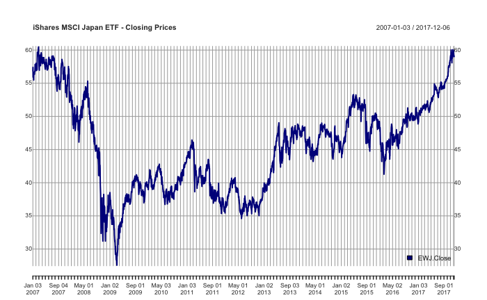

```r
library(xts)
plot.xts(ts, main = "iShares MSCI Japan ETF - Closing Prices", col = "darkblue", auto.legend = TRUE, legend.loc = "bottomright") # Plot the ETF's historical closing prices
```

The ETF suffered a huge downturn that saw its net asset value more than halved during the 2008 financial crisis before climbing back again to new highs as of early December, 2017.

## Time series analysis

It is clear from the timeplot above the closing prices’ time series is anything but stationary, as it wanders up and down over for sustained periods. A formal Augmented Dickey-Fuller (ADF) test below also does not reject the null hypothesis of non-stationarity.

```r
library(tseries) # Load the tseries package for Augmented Dickey-Fuller Test
adf.test(ts, alternative = "stationary") # Run the ADF test to verify stationarity
```

```
    Augmented Dickey-Fuller Test

data:  ts
Dickey-Fuller = -1.9516, Lag order = 14, p-value = 0.5988
alternative hypothesis: stationary
```

Therefore, we need to take the first difference of the time series, which involves subtracting the previous entry’s value from the value of the current period.

```r
ts.diff <- diff(ts)[-1, ] # Take the first difference on the time series and remove the first row which contains NA
head(ts.diff) # Check the first few rows
```

```
           EWJ.Close
2007-01-04  0.600003
2007-01-05 -1.480004
2007-01-08  0.320004
2007-01-09  0.359996
2007-01-10 -0.840000
2007-01-11 -0.279998
```

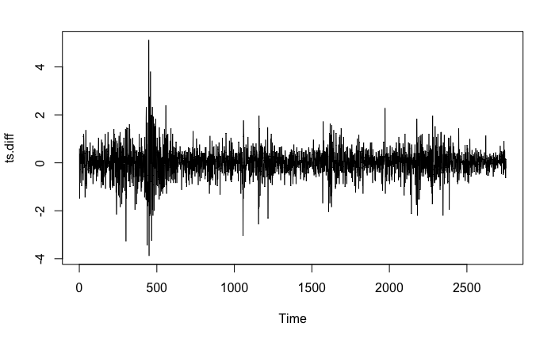

```r
ts.plot(ts.diff) # Plot the new differenced series
```

```r
adf.test(ts.diff, alternative = "stationary") # Run the ADF test to verify stationarity
```

```
p-value smaller than printed p-value
```

```
    Augmented Dickey-Fuller Test

data:  ts.diff
Dickey-Fuller = -15.416, Lag order = 14, p-value = 0.01
alternative hypothesis: stationary
```

The plot of our new differenced series shows an oscillating pattern around zero with no visible clear trend. More importantly, the ADF test result rejects the null hypotheses of non-stationarity, suggesting the series most likely conforms to stationarity and thus differencing of order 1 is sufficient.

Regarding the order parameters for ARIMA modeling, the autocorrelation function (ACF) plot below indicates significant autocorrelations at lag 1 and 16, while the partial autocorrelation function (PACF) plot points out significant autocorrelations at lag 1, 2, 5, and beyond.

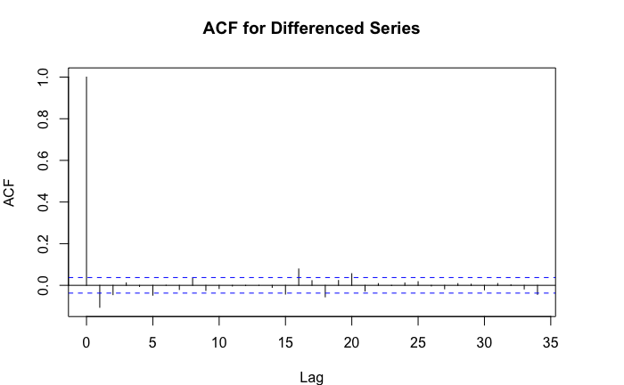

```r
par(mar = c(4, 4, 4, 4)) # Adjust for the right graphic margins
acf(ts.diff, main = "ACF for Differenced Series") # Check for MA lags
```

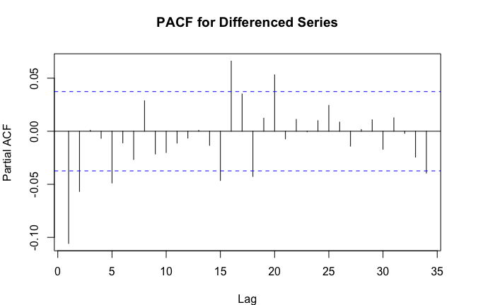

```r
pacf(ts.diff, main = "PACF for Differenced Series") # Check for AR lags
```

Then we apply the original time series of the ETF’s closing prices to the **`auto.arima`** function.

```r
library(forecast) # Load the forecast package for fitting the series data to the ARIMA model
ts.arima <- auto.arima(ts) %>% # Fit and print out the ARIMA model
  print()
```

```
Series: ts
ARIMA(3,1,4)

Coefficients:
         ar1      ar2     ar3      ma1     ma2      ma3     ma4
      0.0486  -0.4046  0.7399  -0.1609  0.3679  -0.7910  0.0553
s.e.  0.1196   0.1068  0.1127   0.1217  0.0953   0.0986  0.0296

sigma^2 estimated as 0.3315:  log likelihood=-2382.3
AIC=4780.61   AICc=4780.66   BIC=4827.97
```

The result recommends ARIMA(3,1,4) model. However, before we rush to make some forecasts, we need to examine the ACF and PACF plots for model residuals to see if this ARIMA(3,1,4) model is trustworthy enough.

```
    Ljung-Box test

data:  Residuals from ARIMA(3,1,4)
Q* = 13.919, df = 3, p-value = 0.003018

Model df: 7.   Total lags used: 10
```

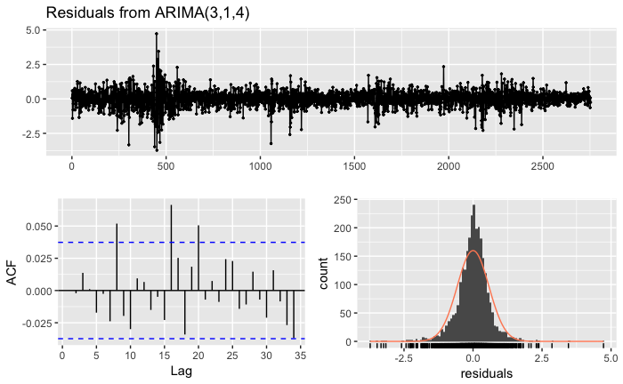

```r
checkresiduals(ts.arima) # Check the model residuals for normality and autocorrelations
```

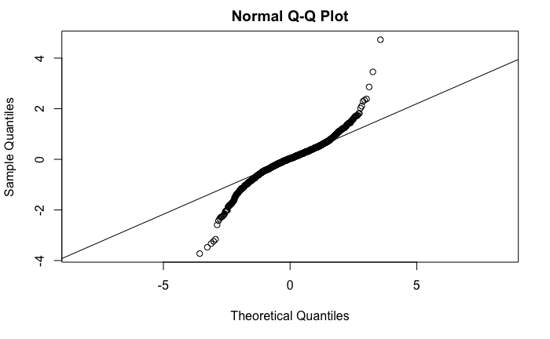

```r
qqnorm(ts.arima$residuals, asp = 1) # Check the model residuals' QQ plot to inspect normality
qqline(ts.arima$residuals, asp = 1)
```

The Ljung-Box test returns a significant p-value for model residuals, and the ACF plot indicates significant autocorrelations at lag 8, 16, and beyond. Both the histogram and the QQ plot for model residuals point towards non-normality as well.

Furthermore, both the model residuals plots above and the previously mentioned ACF plot for the differenced series reveal clear statistical significance at lag 16. This suggests our ARIMA model can probably be further improved with a specification of *q = 16*.

```r
ts.arima.ma16 <- Arima(ts, order = c(3,1,16)) #  Fit and print out the revised ARIMA model
print(ts.arima.ma16)
```

```
Series: ts
ARIMA(3,1,16)

Coefficients:
         ar1      ar2     ar3      ma1     ma2      ma3     ma4      ma5     ma6      ma7     ma8
      0.1786  -0.2390  0.4740  -0.2896  0.2190  -0.4903  0.0274  -0.0265  0.0024  -0.0157  0.0497
s.e.  0.1624   0.1289  0.1668   0.1621  0.1269   0.1611  0.0308   0.0235  0.0240   0.0234  0.0244
          ma9    ma10     ma11    ma12    ma13    ma14     ma15    ma16
      -0.0385  0.0069  -0.0137  0.0072  0.0037  -0.007  -0.0304  0.0889
s.e.   0.0232  0.0232   0.0225  0.0226  0.0219   0.022   0.0213  0.0205

sigma^2 estimated as 0.329:  log likelihood=-2365.91
AIC=4771.83   AICc=4772.14   BIC=4890.23
```

```
    Ljung-Box test

data:  Residuals from ARIMA(3,1,16)
Q* = 3.3293, df = 3, p-value = 0.3436

Model df: 19.   Total lags used: 22
```

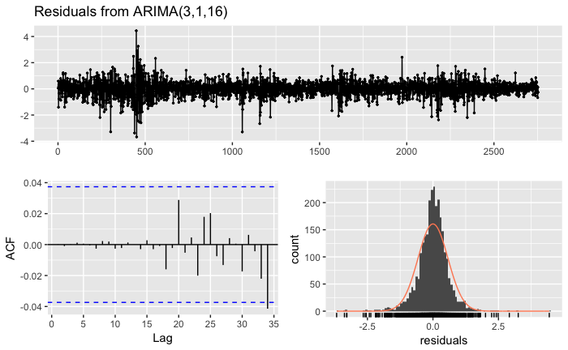

```r
checkresiduals(ts.arima.ma16) # Check the model residuals for normality and autocorrelations
```

Hence, we will go with the *ARIMA(3,1,16)* model for prediction.

## Predictions

Our model’s predictions for the next 30 trading days are presented below.

```
$pred
Time Series:
Start = 2754
End = 2783
Frequency = 1
 [1] 58.92857 58.88037 58.97543 58.97830 58.93015 58.98787 59.04084 59.04497 59.05277 59.09105
[11] 59.08843 59.10097 59.11407 59.05080 59.06161 59.06296 59.03112 59.03073 59.03939 59.02643
[21] 59.02236 59.02933 59.02589 59.02218 59.02613 59.02659 59.02446 59.02633 59.02789 59.02720

$se
Time Series:
Start = 2754
End = 2783
Frequency = 1
 [1] 0.5716241 0.7648486 0.9058750 1.0285959 1.1344711 1.2206903 1.3009651 1.3744501 1.4486116
[10] 1.5137582 1.5746140 1.6337955 1.6902027 1.7443838 1.7963133 1.8425237 1.8984478 1.9555451
[19] 2.0068774 2.0605891 2.1158045 2.1673775 2.2183671 2.2701096 2.3198875 2.3683206 2.4167642
[28] 2.4641345 2.5102294 2.5558946
```

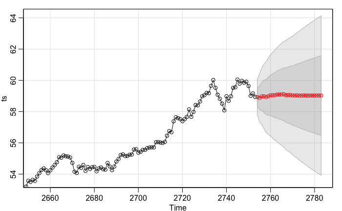

```r
library(astsa)
ts.prediction <- sarima.for(ts, n.ahead = 30, 3, 1, 16) %>%
  print() # Generate our ARIMA model's 30-day predictions
```

Are these predictions reliable?

We designate the past 30 trading days in our time series as the “hold-out” set, fit our chosen ARIMA model, and see how well the predictions fit the actual observed values.

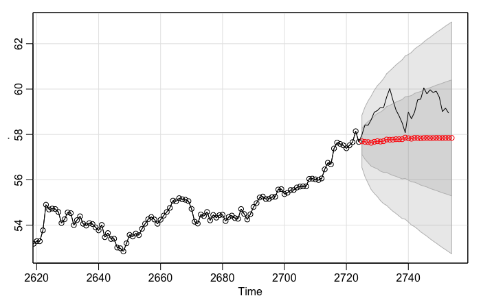

```r
ts.trun <- window(ts, end = time(tail(ts, n = 30)[1])) %>%
  sarima.for(n.ahead = 30, 3, 1, 16) # Back test our ARIMA model
lines.default(ts)
```

The red circles represent the predicted values for the past 30 trading days, forming a nearly straight line very quickly, which is odd given the series’ predominantly oscillating pattern.

Nonetheless, most of the actual observed values (i.e. the black line) do fall within the bounds of the 80% confidence levels (i.e. the dark grey shaded areas), hence lending our current model some degree of credibility.

## Conclusions

This post presents a simple demonstration of using ARIMA modeling for predicting an ETF’s price movements, and our model, at its current form, remains fairly naive.

More refinements on the model might be obtained from segmenting out bull run periods from bear run periods for more sophisticated analysis. Further insights might also come from testing other forecasting models, such as the [ets models](https://ellisp.github.io/blog/2016/11/27/ets-friends), but those would be left for future exploration.